# Eyeballing Parameters

For each graph, choose an appropriate function form to represent the pattern shown by the data and estimate, by eye, the parameters that will fit the data.

The fraction of US households with a telephone, as a function of family income. (Source: Susan E. Mayer (1997) **What money can't buy: Family income and children's life chances** Harvard Univ. Press p. 102.)

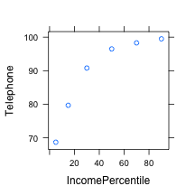

```r
inc = fetchData("Income-Housing.csv")
plotPoints( Telephone ~ IncomePercentile, data=inc)
```

Stan Wagon's measurements of the temperature of a water. The water was boiled and poured into the mug. (Source: Stan Wagon and Robert Portmann, “How quickly does hot water cool?”, *Mathematica in Education and Research* **10**:3 (July 2005) 1-9.)

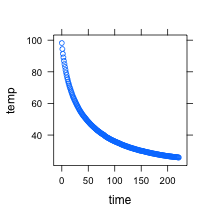

```r
stan = fetchData("stan-data.csv")
plotPoints( temp ~ time, data=stan)
```

[output not shown]

Time variable is measured as a Julian date; 0 is Greenwich noon, on 1 January 4713 BC. Radii are in astronomical units (AU) — the mean distance from the Earth to the Sun.

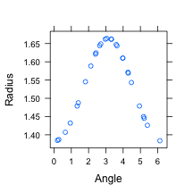

```r
kdata = fetchData("kepler-mars.csv")
plotPoints( kepler.radius ~ kepler.angle,
    data=kdata,
    xlab="Angle",ylab="Radius" )
```

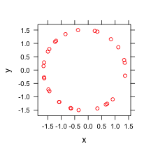

```r
kdata = transform(kdata, x=kepler.radius*cos(kepler.angle))
kdata = transform(kdata, y=kepler.radius*sin(kepler.angle))
plotPoints(y~x, data=kdata,col="red")
```

Tidal measurements in Pearl Harbor, Hawaii. (Source: Andrew Beveridge)

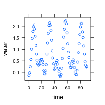

```r
h = fetchData("hawaii.csv")
plotPoints(water ~ time, data=h)
```

Data about the size, power, and other characteristics of internal combustion engines. (Source: Thomas McMahon and John Tyler Bonner (1983) *On Size and Life*)

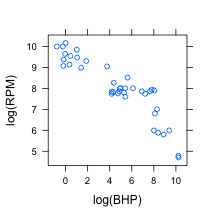

```r
engines = fetchData("engines.csv")
plotPoints(log(RPM)~log(BHP), data=engines)
```

Residual life expectancy versus age in the US. US Census Bureau.

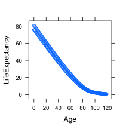

```r
LE = fetchData("LifeExpectancy.csv")
plotPoints(LifeExpectancy ~ Age, data=LE)
```

Keeling's record of atmospheric carbon dioxide from Mauna Loa, 1958-2008. http://cdiac.ornl.gov/trends/co2/sio-mlo.html

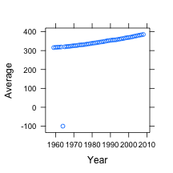

```r
CO2 = fetchData("maunaloa-CO2.csv")
plotPoints( Average ~ Year, data=CO2)
```

The number of O-ring failures in each Space Shuttle launch up to the 1986 Challenger accident.

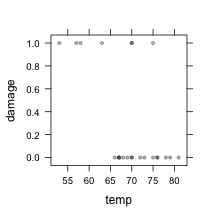

```r
oring = fetchData("oring-damage.csv")
plotPoints(damage ~ temp, data=oring,
           pch=20, col=rgb(0,0,0,.3))
```

Data from a problem in Stewart, giving world population versus year.(Source: Stewart, **Calculus: Concepts and Contexts** 2/e p. 38.

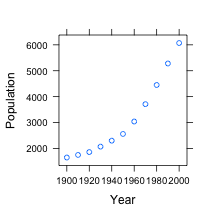

```r
worldPop = fetchData("PREP-Stewart-World-Population.csv")
plotPoints(Population ~ Year, data=worldPop )
```

Month-by-month utility bill data from a single-family house in Saint Paul, Minnesota.

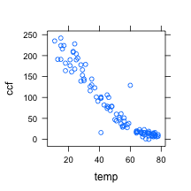

```r
utils = fetchData("utilities.csv")
plotPoints(ccf ~ temp, data=utils)
```

The radius of the fireball versus time measured at the first atomic bomb test, Trinity in Alamogordo, New Mexico, on July 16, 1945.

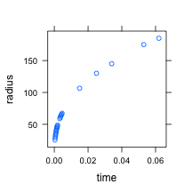

```r
blast = fetchData("blastdata.csv")
plotPoints(radius ~ time, data=blast)
```

Body circumference measurements for 252 men, along with estimates of the percentage of body fat determined by underwater weighing. (Source: [StatLib](http://lib.stat.cmu.edu/datasets/bodyfat). See also a discussion by [Victor Addona](http://www.mosaic-web.org/go/MCAST/materials/Sept-10-2010/Addona_MCAST_Sept_10.pdf).)

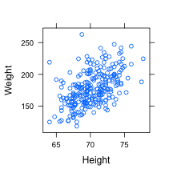

```r
body = fetchData("BodyFat.csv")
body = subset(body, Height>60 & Weight<300 )
plotPoints(Weight ~ Height, data=body)
```

Data on used Honda Accords collected by a student group in Macalester's Math 155 class. (Contact: Daniel Kaplan, Macalester College)

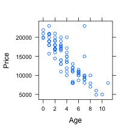

```r
cars = fetchData("used-hondas.csv")
plotPoints(Price ~ Age, data=cars)
```